# Time series, prediction, and forecasting

For most of this section, we will draw from material in Bailey’s *Real Econometrics*, Chapter 14 of my supplementary material, and:

> Hyndman, R.J., & Athanasopoulos, G. (2018) [Forecasting: principles and practice](https://otexts.com/fpp2/), 2nd edition, OTexts: Melbourne, Australia.

## Introduction

Up to this point we have almost exclusively focused on estimating causal effects. While we will by no means ignore this altogether in this section, we will also have an added focus on prediction and forecasting. That is, since we have data on more than one time period, it is natural that we may want to make a prediction about something that happens *after* our sample is collected. As a motivating example, consider the following data on time series from the [US Energy Information Administration website](https://www.eia.gov/dnav/pet/pet_pri_gnd_dcus_nus_w.htm)

```r
library(tidyr)
library(dplyr)
library(ggplot2)
library(lubridate)

D<-(read.csv("Data/Weekly_Retail_Gasoline_and_Diesel_Prices.csv",skip=6)
  %>% data.frame()
)
colnames(D)<-c("Week","Price")

D<-D %>% mutate(Week = mdy(Week)) %>% arrange(Week) %>% mutate(Month=month(Week))

Dts<-ts(D,start=1995,frequency=52)

knitr::kable(head(D))
```

| Week | Price | Month |
| --- | --- | --- |
| 1993-04-05 | 1.068 | 4 |
| 1993-04-12 | 1.079 | 4 |
| 1993-04-19 | 1.079 | 4 |
| 1993-04-26 | 1.086 | 4 |
| 1993-05-03 | 1.086 | 5 |
| 1993-05-10 | 1.097 | 5 |

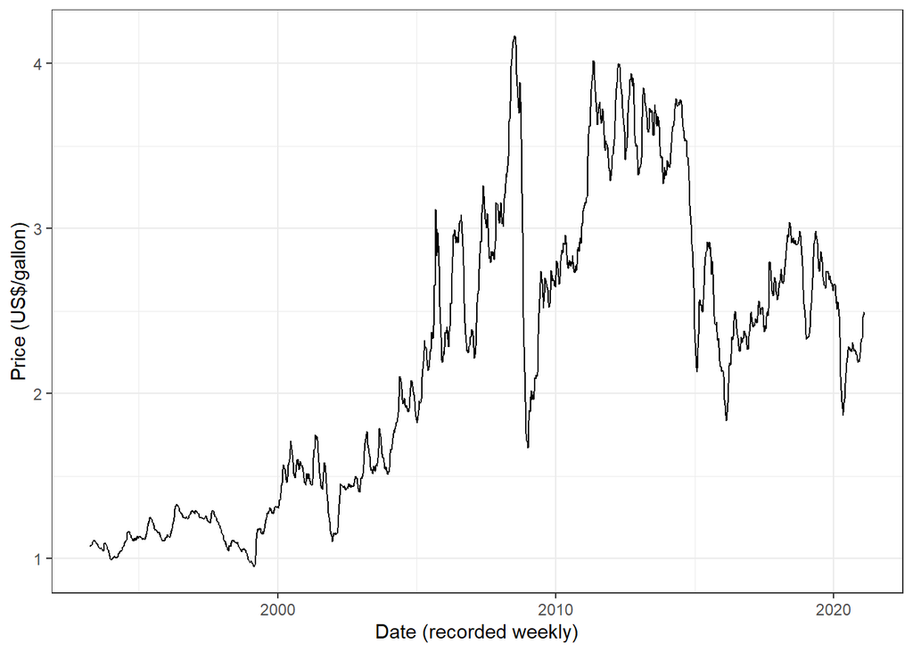

```r
(
  ggplot(D,aes(x=Week,y=Price))
  +geom_line()
  +xlab("Date (recorded weekly)")+ylab("Price (US$/gallon)")
  +theme_bw()
)
```

## Notation

$$Y_t = \text{our outcome variable measured in time period }t$$
$$Y_{t-1} = Y \text{ from one time period ago (1-period lag)}$$
E.g. in linear regression:
$$\begin{aligned}
Y_t&= \beta_0+\beta_1Y_{t-1}+\epsilon_t\\
E[Y_t\mid Y_{t-1}]&=\beta_0+\beta_1Y_{t-1}
\end{aligned}$$

$$Y_{t+1}=Y \text{ one time period into the future (1-period forward or lead)}$$

## Building blocks

**Autoregrssive model**

$$Y_t=\beta_0+\sum_{l=1}^L\beta_lY_{t-l}+\epsilon_t\quad\text{AR(L)}$$

e.g.: If $\beta_l=\frac1L$ (and $\beta_0=0$), then this is a moving-average forecast.

**Moving average model**
$$Y_t=\beta_0+\sum_{l=1}^L\gamma_l\epsilon_{t-l}+\epsilon_t \quad\text{MA(L)}$$
**Autorgresive moving average model**
$$Y_t=\beta_0+\sum_{l=1}^{L_1}\beta_lY_{t-l}+\sum_{l=1}^{L_2}\gamma_l\epsilon_{t-l}+\epsilon_t\quad \text{ARMA}(L_1,L_2)$$

## Diagnostics

### ACF and PACF

**Autocorrelation function**
$$R(\tau)=\frac{E[(Y_t-\mu)(Y_{t-\tau}-\mu)]}{V(Y_t)}$$

For an AR process:
$$\begin{align}
Y_t&=\beta_0+\sum_{l=1}^L\beta_lY_{t-l}+\epsilon_t
\end{align}$$

1. Assume stationarity - $E(Y_t)$ does not depend on $t$
   $$\begin{align}
   E[Y_t]&=E\left[\beta_0+\sum_{l=1}^L\beta_lY_{t-l}+\epsilon_t\right]\\
   &=\beta_0+\sum_{l=1}^L\beta_lE[Y_{t-l}]+E[\epsilon_t]\\
   &=\beta_0+\sum_{l=1}^L\beta_lE[Y_{t}]+\underbrace{E[\epsilon_t]}_{=0}\quad\text{imposed stationarity here}\\
   &=\beta_0+E[Y_{t}]\sum_{l=1}^L\beta_l\\
   E[Y_t]\left(1-\sum_{l=1}^L\beta_l\right)&=\beta_0\\
   E[Y_t]&=\frac{\beta_0}{1-\sum_{l=1}^L\beta_l}
   \end{align}$$
   Simplifying for AR(1):
   $$E[Y_{t}]=\frac{\beta_0}{1-\beta_1}$$
   Problem if $|\beta_1|\geq 1$: E.g.:

$$\begin{align}
Y_t&=\beta_1Y_{t-1}+\epsilon_t\quad |\beta_1|>1\\
E[Y_{t}\mid Y_{t-1}]&=\beta_1Y_{t-1}\\
E[E[Y_{t}\mid Y_{t-1}]]&=E[\beta_1Y_{t-1}]\\
E[Y_t]&=\beta_1E[Y_{t-1}]
\end{align}$$

2. Calculate covariance (assume $\beta_0=0\implies \mu=0$)

$$\begin{aligned}
E[(Y_t-\mu)(Y_{t-\tau}-\mu)]&=E[Y_tY_{t-\tau}]\\
&=E\left[\left(\sum_{l=1}^L\beta_lY_{t-l}+\epsilon_t\right)Y_{t-\tau}\right]\\
&=E\left[Y_{t-\tau}\sum_{l=1}^L\beta_lY_{t-l}+Y_{t-\tau}\epsilon_t\right]\\
&=\sum_{l=1}^L\beta_lE[Y_{t-\tau}Y_{t-l}]+\underbrace{E[Y_{t-\tau}\epsilon_t]}_{=0}\\
&=\sum_{l=1}^L\beta_lE[Y_{t-\tau}Y_{t-l}]\\
&=\sum_{l=1}^L\beta_l\mathrm{cov}(Y_{t-\tau},Y_{t-l})
\end{aligned}$$
$$\begin{align}
Y_0&=y_0\quad\text{(given)}\\
Y_1&=\beta_1y_0+\epsilon_1\\
Y_2&=\beta_1(\beta_1y_0+\epsilon_1)+\epsilon_2\\
Y_3&=\beta_1\overbrace{(\beta_1\underbrace{(\beta_1y_0+\epsilon_1)}_{Y_1}+\epsilon_2)}^{Y_2}+\epsilon_3\\
Y_t&=y_0\beta_1^t+ \sum_{l=0}^{t}\beta_1^{l}\epsilon_{t-l}
\end{align}$$

## Autocorrelated errors

AR(1) errors:

$$\begin{aligned}
Y_{t}&=\beta_0+\beta_1X_t+\epsilon_t\\
\epsilon_t&=\rho\epsilon_{t-1}+\nu_t,\quad \nu_t \sim \text{independent}
\end{aligned}$$

Goal: eliminate $\epsilon_t$:
$$\begin{aligned}
\rho Y_{t-1}&=\rho\beta_0+\rho\beta_1X_{t-1}+\rho\epsilon_{t-1}\\
Y_t-\rho Y_{t-1}&=\beta_0+\beta_1X_t+\epsilon_t-\rho\beta_0-\rho\beta_1X_{t-1}-\rho\epsilon_{t-1}\\
&=(1-\rho)\beta_0+\beta_1(X_t-\rho X_{t-1})+(\epsilon_t-\rho\epsilon_{t-1})\\
\epsilon_t-\rho\epsilon_{t-1}&=\rho\epsilon_{t-1}+\nu_t-\rho\epsilon_{t-1}=\nu_t\\
Y_t-\rho Y_{t-1}&=(1-\rho)\beta_0+\beta_1(X_t-\rho X_{t-1})+\nu_t
\end{aligned}$$

Sample dataset

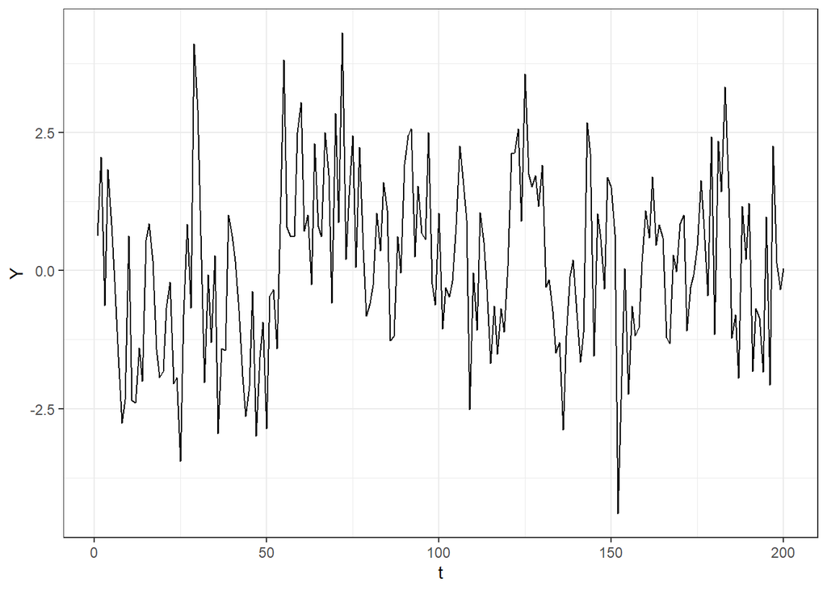

```r
library(ggplot2)
rho<-0.2

FakeData<-function(rho,b1,n) {
  nu<-rnorm(n)
  X<-rnorm(n)
  eps<-c(nu[1])
  for (tt in 2:n) {
    eps[tt]<-rho*eps[tt-1]+nu[tt]
  }
  Y<-b1*X+eps
  t<-1:n
  data.frame(t,nu,eps,Y,X)
}

D<-FakeData(0.7,1,200)
(
  ggplot(D,aes(y=Y,x=t))
  +geom_line()
  +theme_bw()
)
```

```r
library(stargazer)
library(orcutt)
library(timeSeries)
library(tidyr)
library(dplyr)

# Bivariate OLS
lm1<-lm(data=D,Y~X)

# rho-transform
lm2<-cochrane.orcutt(lm1)

# estimate rho-transform without using orcutt package
resid<-lm1$residuals
t<-1:length(resid)
residuals<-(data.frame(t,resid)
            %>% mutate(lagResid = lag(resid,k=1))
)
lm3<-lm(data=residuals,resid~lagResid)
rhoHat<-lm3$coefficients["lagResid"]
D<-(D
  %>% mutate(Ytilde = Y-rhoHat*lag(Y,k=1),
              Xtilde = X-rhoHat*lag(X,k=1))
)

lm4<-lm(data=D,Ytilde ~ Xtilde)




stargazer(lm1,lm2,lm3,lm4,type="html")
```

|  | *Dependent variable:* |  |  |  |
| --- | --- | --- | --- | --- |
|  | Y |  | resid | Ytilde |
|  | (1) | (2) | (3) | (4) |
| X | 0.895*** | 0.932*** |  |  |
|  | (0.091) | (0.056) |  |  |
| lagResid |  |  | 1.000*** |  |
|  |  |  | (0.000) |  |
| Xtilde |  |  |  | 0.865*** |
|  |  |  |  | (0.090) |
| Constant | 0.018 | 0.012 | 0.000 | -0.000 |
|  | (0.092) | (0.204) | (0.000) | (0.000) |
| Observations | 200 | 200 | 200 | 200 |
| R<sup>2</sup> | 0.326 |  | 1.000 | 0.320 |
| Adjusted R<sup>2</sup> | 0.323 |  | 1.000 | 0.316 |
| Residual Std. Error (df = 198) | 1.297 |  | 0.000 | 0.000 |
| F Statistic (df = 1; 198) | 95.868*** |  | 5,380,963,398,465,840,659,626,866,806,802,248.000*** | 93.144*** |
| *Note:* | p<0.1; p<0.05; p<0.01 |  |  |  |

```r
SimSize<-1000

SIMULATION<-data.frame()

for (ss in 1:SimSize) {
  FD<-FakeData(0.9,0,1000)
  lm1<-lm(data=FD,Y~X)

  d<-data.frame(summary(lm1)$coefficients)
  d$method<-"OLS"
  d$coefficient<-rownames(d)
  SIMULATION<-d %>% rbind(SIMULATION)

  lm2<-cochrane.orcutt(lm1)

  d<-data.frame(summary(lm2)$coefficients)
  d$method<-"rho-transform"
  d$coefficient<-rownames(d)
  SIMULATION<-d %>% rbind(SIMULATION)

}

SIMULATION %>% head() %>% knitr::kable()
```

|  | Estimate | Std..Error | t.value | Pr…t.. | method | coefficient |
| --- | --- | --- | --- | --- | --- | --- |
| (Intercept) | -0.4744527 | 0.2760166 | -1.719000 | 0.0859379 | rho-transform | (Intercept) |
| X | -0.0088851 | 0.0230038 | -0.386000 | 0.6993978 | rho-transform | X |
| (Intercept)1999 | -0.4292744 | 0.0667412 | -6.431927 | 0.0000000 | OLS | (Intercept) |
| X1999 | 0.1867221 | 0.0656610 | 2.843729 | 0.0045499 | OLS | X |
| (Intercept)1998 | -0.1289657 | 0.3305821 | -0.390000 | 0.6965333 | rho-transform | (Intercept) |
| X1998 | 0.0014187 | 0.0236252 | 0.060000 | 0.9521284 | rho-transform | X |

$$H_0: \ \beta_1=0,\quad H_A: \beta_1\neq 1$$

```r
SIMULATION %>% group_by(coefficient,method) %>% summarize(rejectProb = mean(1*(Pr...t..<0.05)))  %>% knitr::kable()
```

| coefficient | method | rejectProb |
| --- | --- | --- |
| (Intercept) | OLS | 0.644 |
| (Intercept) | rho-transform | 0.053 |
| X | OLS | 0.062 |
| X | rho-transform | 0.052 |

[output not shown]

[figure not shown]

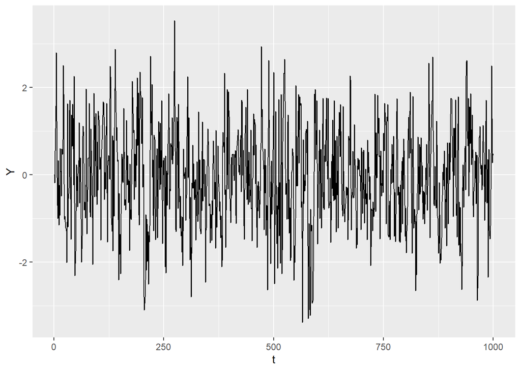

```r
(ggplot(d,aes(y=Y,x=t)))+geom_line()
```

Effect of $X_t$ on $Y_{t+k}$:
$$\begin{aligned}
t:&\ \beta_1\\
t+1:&\ \beta_1\gamma\\
t+k:&\ \beta_1\gamma^{k}
\end{aligned}$$
Effect on *all* $Y$ in the future added up:
$$\beta_1(1+\gamma+\gamma^2+\gamma^3+\ldots)=\frac{\beta}{1-\gamma}$$

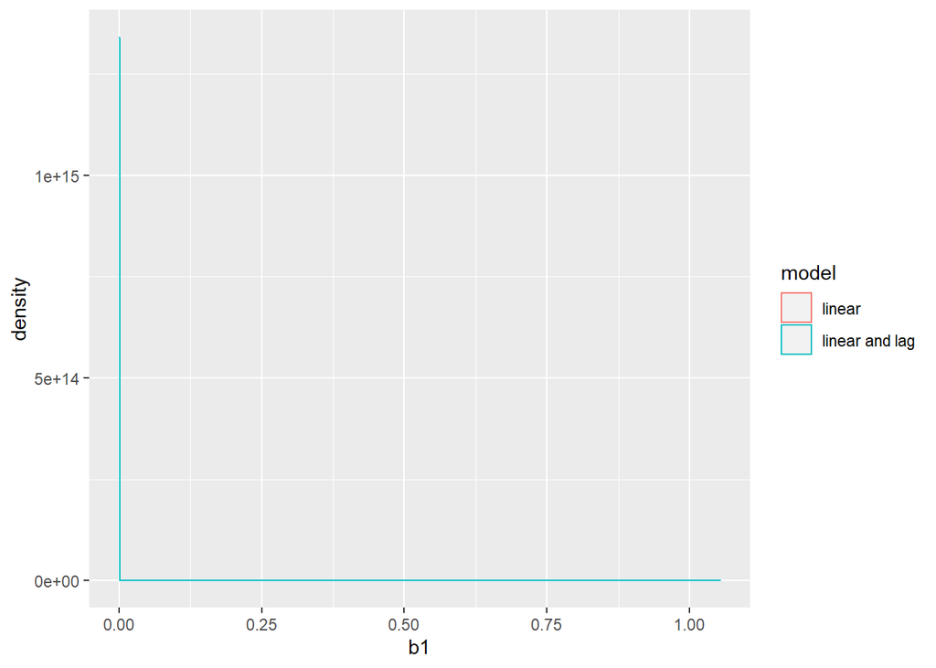

```r
Estimates<-function(b,g){
  data<-FakeData(b,g)
  model1<-lm(data,formula = Y ~ X)
  model2<-lm(data,formula = Y ~ X+lag(Y,1))

  c(model1$coefficients["X"],model2$coefficients["X"])
}
Simulation<-data.frame()
for (ss in 1:1000) {

  Simulation<-  data.frame(Estimates(1,0.5),c("linear","linear and lag")) %>% data.frame( ) %>% rbind(Simulation)
}
colnames(Simulation)<-c("b1","model")

(ggplot(Simulation,aes(x=b1,color=model)))+geom_density()
```

```r
Simulation %>% group_by(model) %>% summarize(mean = mean(b1),
                                             sdSimulation = sd(b1)/sqrt(n()),
  RMSE = sqrt(mean((b1-1)^2))) %>% knitr::kable()
```

| model | mean | sdSimulation | RMSE |
| --- | --- | --- | --- |
| linear | 0.9978277 | 0.0005579 | 0.017767 |
| linear and lag | 0.0000000 | 0.0000000 | 1.000000 |

for the standard deviation of simulation
$$\hat\beta_1\sim iid \ E[\hat\beta_1]=\mu, \ V[\hat\beta_1]=\sigma^2\\
\frac{\sqrt{s}(\frac{1}{S}\sum_{s=1}^S\hat\beta_{1,s}-E[\hat\beta_1])}{\sigma}\xrightarrow[]{d}N(0,1)\\
V\left[\frac{1}{S}\sum_{s=1}^S\hat\beta_{1,s}\right]\approx\sigma^2/s$$

## A brief digression into collider bias

Model: Actors must be at least one of (1) good looking, and (2) a good actor.

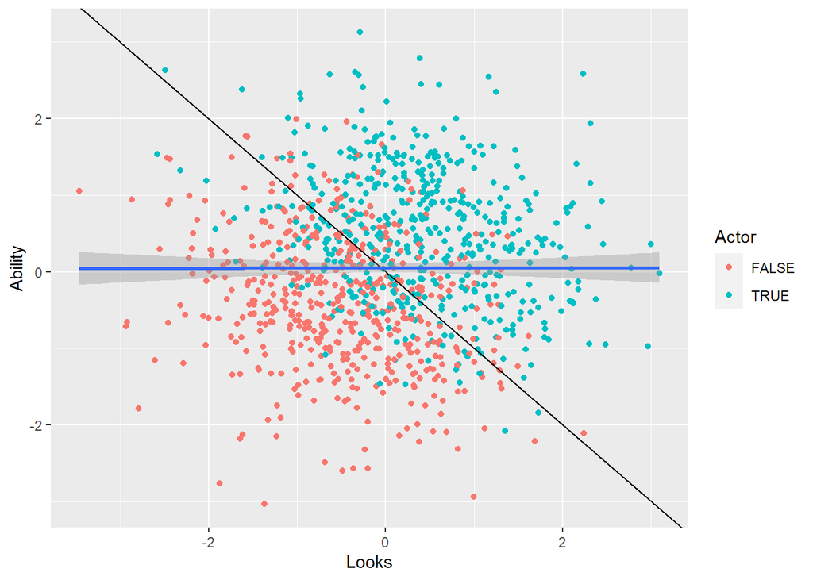

```r
Ability<-rnorm(1000)
Looks<-rnorm(1000)
Actor = (Ability+Looks)>rnorm(1000)
d<-data.frame(Ability,Looks,Actor)

ggplot()+geom_point(data=d,aes(x=Looks,Ability,color=Actor))+geom_abline(slope=-1,intercept=0)+geom_smooth(data=d,aes(x=Looks,Ability),method="lm")
```

```r
m1<-lm(data=d,Ability~Looks)
m2<-lm(data=d,Ability~Looks+Actor)

stargazer(m1,m2,type="text")
```

```
##
## ================================================================
##                                 Dependent variable:
##                     --------------------------------------------
##                                       Ability
##                             (1)                   (2)
## ----------------------------------------------------------------
## Looks                      0.001               -0.253***
##                           (0.031)               (0.029)
##
## Actor                                           1.132***
##                                                 (0.060)
##
## Constant                   0.050               -0.526***
##                           (0.031)               (0.040)
##
## ----------------------------------------------------------------
## Observations               1,000                 1,000
## R2                        0.00000                0.265
## Adjusted R2               -0.001                 0.264
## Residual Std. Error  0.979 (df = 998)       0.840 (df = 997)
## F Statistic         0.002 (df = 1; 998) 180.150*** (df = 2; 997)
## ================================================================
## Note:                                *p<0.1; **p<0.05; ***p<0.01
```

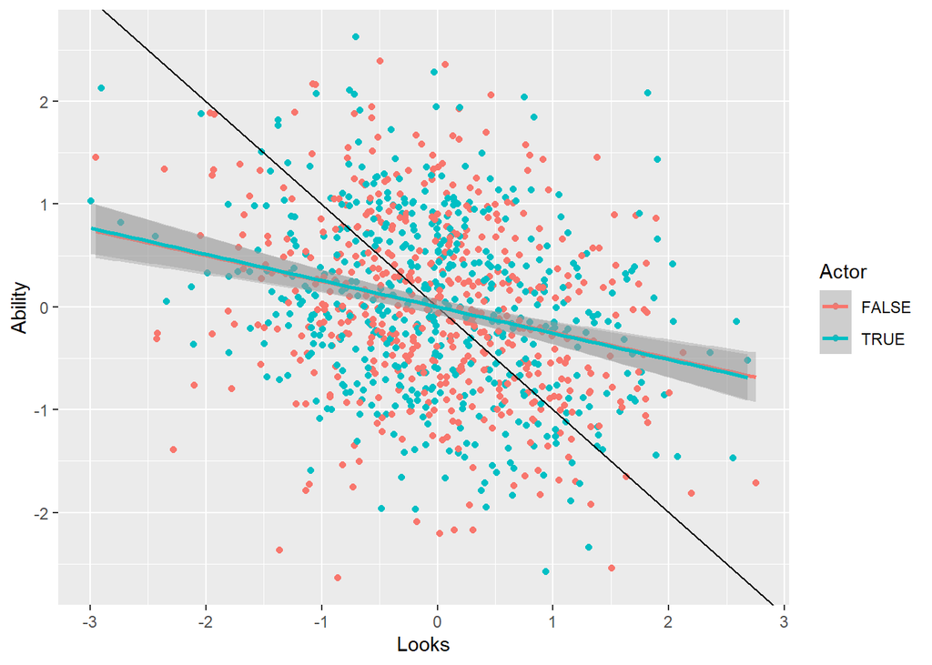

```r
d_dm<-d %>% group_by(Actor) %>% mutate(Looks = Looks-mean(Looks),Ability = Ability-mean(Ability))

ggplot(d_dm,aes(x=Looks,Ability,color=Actor))+geom_point()+geom_abline(slope=-1,intercept=0)+geom_smooth(method="lm")
```

$$\begin{aligned}
\text{Ability} &\xrightarrow[]{}\text{Actor}\\
\text{Looks} &\xrightarrow[]{}\text{Actor}\\
&\quad\text{we want to estimate:}\\
\text{Ability}&\xrightarrow[]{}\text{Looks}
\end{aligned}$$

**If $Y_{t-1}$ *shouldn’t* be on the RHS**

Real model
$$Y_t=\beta_1X_t+\epsilon_t, \quad X_t=\rho X_{t-1}+\nu_t$$
Estimated model:
$$y_t=\gamma Y_{t-1}+\beta_1X_t+\epsilon_t$$

$$\begin{aligned}
X_t &\xrightarrow[]{}Y_t\\
X_{t-1} &\xrightarrow[]{}X_t\\
X_{t}&\xrightarrow[]{}X_{t+1}\xrightarrow[]{}Y_{t+1}\\
&\quad\text{we want to estimate:}\\
Y_{t-1}\xleftarrow[]{}X_{t-1}\xrightarrow[]{}X_{t}
\end{aligned}$$

```r
FakeData<-function(b,g) {
  E<-0.1*rnorm(100)

X<-0
  for (tt in 2:length(E)) {
    X[tt]<-g*X[tt-1]+0.1*rnorm(1)
  }
  t<-1:length(X)
  Y<-b*X+E
  data.frame(X,Y,t)
}
Estimates<-function(b,g){
  data<-FakeData(b,g)
  model1<-lm(data,formula = Y ~ X)
  model2<-lm(data,formula = Y ~ X+lag(Y,1))
  model3<-lm(data,formula = Y ~ lag(Y,1))

  c(model1$coefficients["X"],model2$coefficients["X"],model3$coefficients["lag(Y, 1)"])
}

Simulation<-data.frame()

for (ss in 1:1000) {

  Simulation<-  data.frame(Estimates(1,0.9),c("Y~X","Y~X+lag(Y)","Y~lag(Y)")) %>% data.frame( ) %>% rbind(Simulation)
}
colnames(Simulation)<-c("b1","model")
```

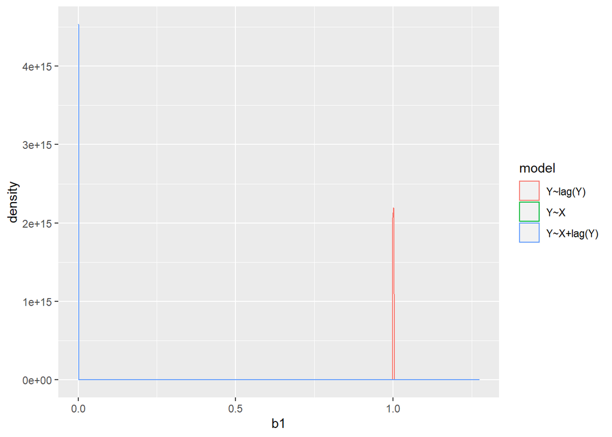

```r
(ggplot(Simulation,aes(x=b1,color=model)))+geom_density()
```

```r
Simulation %>% group_by(model) %>% summarize(mean = mean(b1),
                                             sdSimulation = sd(b1)/sqrt(n())) %>% knitr::kable()
```

| model | mean | sdSimulation |
| --- | --- | --- |
| Y~lag(Y) | 1.000000 | 0.0000000 |
| Y~X | 1.001095 | 0.0016939 |
| Y~X+lag(Y) | 0.000000 | 0.0000000 |

Real data:

```r
# Documentation here: https://vincentarelbundock.github.io/Rdatasets/doc/ggplot2/txhousing.html

Sales<-read.csv("https://vincentarelbundock.github.io/Rdatasets/csv/ggplot2/txhousing.csv")
head(Sales) %>% knitr::kable()
```

| X | city | year | month | sales | volume | median | listings | inventory | date |
| --- | --- | --- | --- | --- | --- | --- | --- | --- | --- |
| 1 | Abilene | 2000 | 1 | 72 | 5380000 | 71400 | 701 | 6.3 | 2000.000 |
| 2 | Abilene | 2000 | 2 | 98 | 6505000 | 58700 | 746 | 6.6 | 2000.083 |
| 3 | Abilene | 2000 | 3 | 130 | 9285000 | 58100 | 784 | 6.8 | 2000.167 |
| 4 | Abilene | 2000 | 4 | 98 | 9730000 | 68600 | 785 | 6.9 | 2000.250 |
| 5 | Abilene | 2000 | 5 | 141 | 10590000 | 67300 | 794 | 6.8 | 2000.333 |
| 6 | Abilene | 2000 | 6 | 156 | 13910000 | 66900 | 780 | 6.6 | 2000.417 |

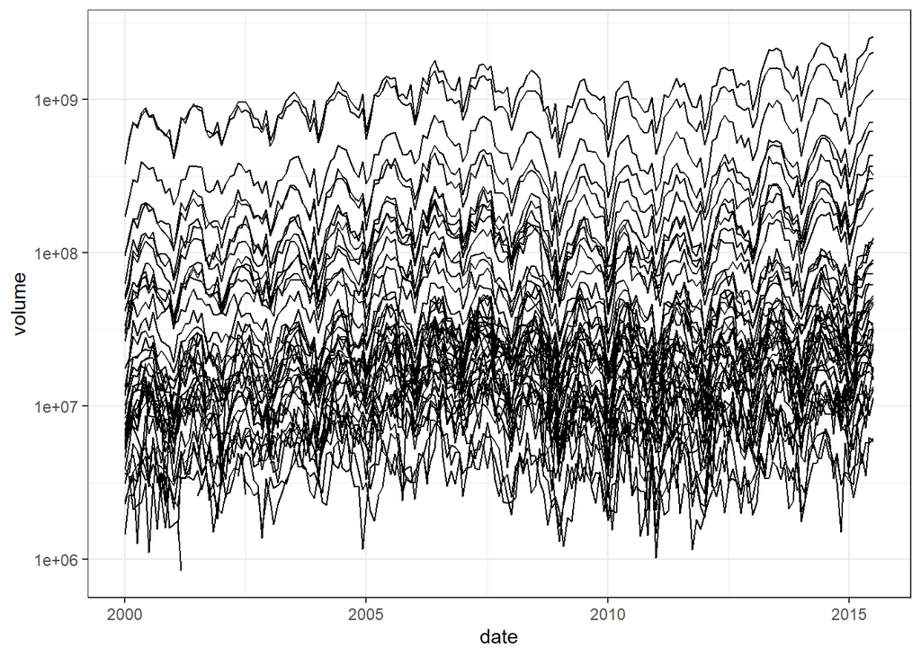

```r
(ggplot(Sales,aes(x=date,y=volume,group=city))+geom_line()+theme_bw())+scale_y_continuous(trans="log10")
```

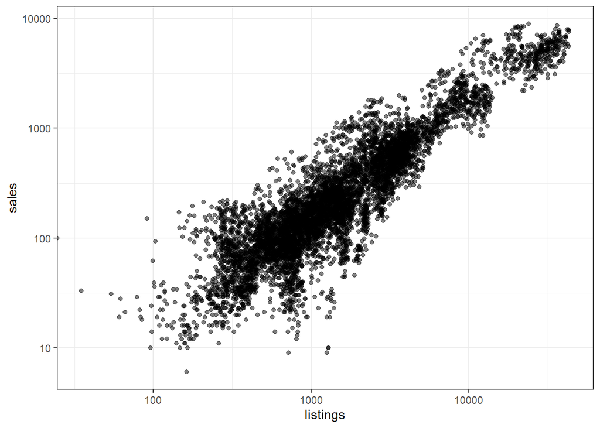

```r
(ggplot(Sales,aes(y=sales,x=listings)))+geom_jitter(alpha=0.5)+theme_bw()+scale_x_continuous(trans="log10")+scale_y_continuous(trans="log10")
```